# Computer Assignment: Reproducible Science and Figures

Candidate 1076523, dinosaur 84

2024-12-08

# Computer Assignment: Reproducible Science and Figures (Michaelmas Term, 2024)

## Question 1: Data visualization for science communication

### a) Provide your figure here:

```
##
##
##
## here() starts at C:/Users/joann/OneDrive/Documents/Computer assignments/Reproducible Science and Figures/Reproducible Science and Figures
```

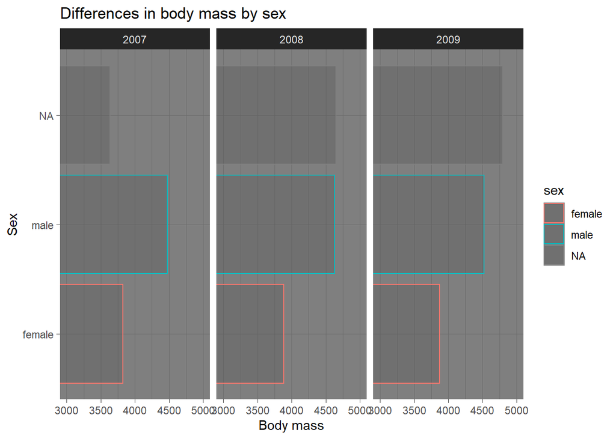

### b) Write about how your design choices mislead the reader about the underlying data:

Data visualization for effective science communication should be based on the following principles: showing the data, making patterns easy to see, honestly representing magnitudes, and clearly drawing graphical elements. (Whitlock and Schluter, 2020) The figure produced above misleads the reader by violating each of these principles.

Firstly, it hides the data by showing only a summary: the mean body mass. This obscures variation within the data and is intended to show categorical variables, rather than continuous ones. This would instead be better represented with a box plot.

Secondly, magnitudes have been dishonestly represented. The X-axis does not start at 0, but instead at 3000g to exaggerate differences in body mass between sexes. This is worsened by the absence of units on the X-axis label, which should include the units, grams.

Patterns are also obscured by swapping the axes around - this makes it much more difficult to compare patterns. This makes it much more difficult to compare the patterns in the data, including patterns among years, than it would have been if sex had been on the X axis.

Finally, graphical elements have not been drawn clearly. There is low contrast between the background of the graph and each of the bars through the use of a dark theme and dark bars with reduced opacity. This is also achieved by using only the colour function, rather than the fill function, to colour the bars by sex. The key also remains messy and difficult to interpret because of the lack of contrast.

Each of these design choices means that the graph provides a misleading representation of the Palmer Penguins data and one that is difficult to reproduce because the code has not been provided.

*References*

Whitlock & Schluter (2020), ‘The analysis of biological data’, Third Edition, Macmillan International Higher Education.

## Question 2: Data pipeline

### Introduction

**Preliminary step:** Loading in packages necessary for this data pipeline

```r
# Loading in packages necessary for this analysis
library(palmerpenguins) # Source of data
library(tidyverse)
library(ggplot2) # Allows plotting of graphs
library(here) # Finding project files based on working directory
library(janitor)
library(dplyr)
library(broom) # Constructing a results table
```

1. **Loading in and cleaning the data**

This analysis sources data collected in the Palmer Archipelago in Antarctica from the palmerpenguins package to investigate the relationship between flipper length and body mass in penguins of three species: Gentoo, Adelie, and Chinstrap.

To start the analysis, the data is loaded in and cleaned. For reproducibility, the data is accessible in both its raw and cleaned forms. In addition, the cleaning process, involving a data pipeline, is shown below.

```r
# Sourcing the cleaning script, which contains the functions needed to clean the data. This is on a separate script for brevity and enhanced reproducibility.
source(here("functions", "cleaning.R"))

# Preserving the raw data by saving it as a .csv file in the data file to make the cleaning process more reproducible.
write_csv(penguins_raw, here("data", "penguins_raw.csv"))

# Load in the raw data, column types are not shown to reduce clutter
penguins_raw <- read_csv(here("data", "penguins_raw.csv"), show_col_types = FALSE)

# A pipeline to clean the raw data, using functions constructed in cleaning.R. Note that the remove_NA function has not been added to this pipeline so that when the data is subsetted for analysis, NAs are removed only from columns of interest.
penguins_clean <- penguins_raw %>%
  clean_column_names() %>%
  remove_columns(c("comments", "delta")) %>%
  shorten_species() %>%
  remove_empty_columns_rows()

# Checking output from the cleaning process
colnames(penguins_clean)
```

```
##  [1] "study_name"        "sample_number"     "species"
##  [4] "region"            "island"            "stage"
##  [7] "individual_id"     "clutch_completion" "date_egg"
## [10] "culmen_length_mm"  "culmen_depth_mm"   "flipper_length_mm"
## [13] "body_mass_g"       "sex"
```

```r
# Saving the clean data using the here library to enable scrutiny and viewing
write_csv(penguins_clean, here("data", "penguins_clean.csv"))
```

2. **Creating an exploratory figure**

An exploratory figure is designed to show the reader raw data, demonstrating its distribution. This enables checking during the analysis to determine whether the data appears as expected. It also allows the construction of hypotheses that can be analysed with statistical methods.

The exploratory scatterplot below shows the relationship between flipper length and body mass across the three penguin species in the data.

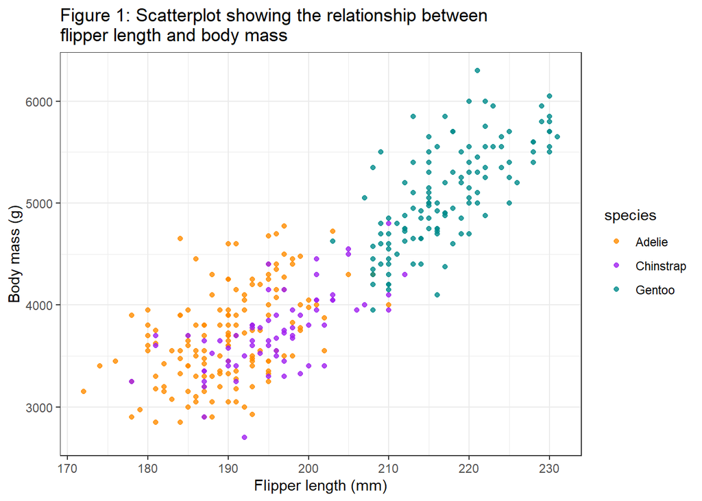

```r
# Removing NAs from the data columns we are using (body_mass_g and flipper_length_mm) to construct the figure. Here, the pipe is used to subset values rather than overwriting.
penguins_flippers_bodymass <- penguins_clean %>%
  select(species, flipper_length_mm, body_mass_g) %>%
  drop_na()

# To enable viewing and scrutiny of the dataset used to construct the graphs, this data (with NAs omitted) is written as a .csv file.

write_csv(penguins_flippers_bodymass,
          here("data", "penguins_flippers_bodymass.csv"))

# Colours with high contrast are defined for the species. This helps make the figure more accessible for colour blind users and by making this character, consistency among plots later in the analysis is made easier, helping the reader to spot patterns.
species_colours <- c("Adelie" = "darkorange",
                    "Chinstrap" = "purple",
                    "Gentoo" = "cyan4")

# Constructing an exploratory scatterplot to visualise the relationship between flipper length and body mass
exploratory_scatterplot <- ggplot(
  data = penguins_flippers_bodymass,
  aes(x = flipper_length_mm,
      y = body_mass_g)) +
  geom_point(
    aes(color = species),
    alpha = 0.8,
    show.legend = TRUE) +
  labs(title =
         "Figure 1: Scatterplot showing the relationship between \nflipper length and body mass",
       x = "Flipper length (mm)",
       y = "Body mass (g)") + # Labels the graph for clarity
  scale_colour_manual(values = species_colours) + # Colours points by species
  theme_bw() # Theme increases contrast to facilitate reading

# View the exploratory figure to visualise the relationship between body mass and flipper length
exploratory_scatterplot
```

### Hypothesis

After visualising the data, I put forward a hypothesis to test: *Penguins with a larger body mass tend to have longer flippers, however, this relationship varies across the three species.*

Body size, generally measured through estimates of body mass, is an important biological property. (Campione and Evans, 2012) It has physiological, morphological, and ecological influence on an organism, including in penguins. It can also be used to learn about extinct species or forms. For example, in paleobiology, single bones like the tarsometatarsi or femora have been used to estimate the body size of extinct Antarctic penguins because this is often the only surviving source of information on these individuals. (Jadwiszczak, 2001; Jadwiszczak and Mors, 2011)

It is therefore interesting to investigate whether flipper length is predictive of body mass in these penguins, and whether this relationship differs among the three species.

### Statistical methods

To test these hypotheses, I begin with a hypothesis test: Pearson’s product-moment correlation. The correlation test measures the linear relationship between variables and was chosen to understand the strength and direction of the relationship (and to check its linearity) before constructing a model.

A strong positive correlation coefficient is indicated by a value of 1, a strong negative correlation coefficient is indicated by a value of -1. Given the shape of the exploratory plot, we expect a value close to 1, indicating a positive correlation between body mass and flipper length.

The null hypothesis tested here is: there is no correlation between flipper length and the body mass of a penguin.

```r
# Performing a correlation test to determine strength and direction of relationship between body mass and flipper length
cor.test(penguins_flippers_bodymass$flipper_length_mm, penguins_flippers_bodymass$body_mass_g, method = "pearson")
```

```
##
##  Pearson's product-moment correlation
##
## data:  penguins_flippers_bodymass$flipper_length_mm and penguins_flippers_bodymass$body_mass_g
## t = 32.722, df = 340, p-value < 2.2e-16
## alternative hypothesis: true correlation is not equal to 0
## 95 percent confidence interval:
##  0.843041 0.894599
## sample estimates:
##       cor
## 0.8712018
```

From the correlation test, it appears that there is a strong, positive correlation between flipper length and the body mass of a penguin. However, more detailed information than this test can provide is required - correlation is not causation.

How the relationship between flipper length and body mass differs across the three penguin species is tested using a linear regression analysis. The assumptions necessary to perform this analysis are tested using a single panel of four diagnostic plots for the reader’s ease of viewing. These assumptions include linearity and equality of variance (shown by residuals vs. fitted plot), normal distribution of data (shown by Q-Q plot), homoscedasticity (shown by scale-location). The most influential observations within the model are shown by the residuals vs. leverage plot.

[output not shown]

```r
# Construct a linear regression model using the lm() function from base R

lm_bodymass_flippers <- lm(body_mass_g ~ flipper_length_mm * species, data = penguins_flippers_bodymass)

# View the results of the model
summary(lm_bodymass_flippers)
```

```
##
## Call:
## lm(formula = body_mass_g ~ flipper_length_mm * species, data = penguins_flippers_bodymass)
##
## Residuals:
##     Min      1Q  Median      3Q     Max
## -911.18 -251.93  -31.77  197.82 1144.81
##
## Coefficients:
##                                     Estimate Std. Error t value Pr(>|t|)
## (Intercept)                        -2535.837    879.468  -2.883  0.00419 **
## flipper_length_mm                     32.832      4.627   7.095 7.69e-12 ***
## speciesChinstrap                    -501.359   1523.459  -0.329  0.74229
## speciesGentoo                      -4251.444   1427.332  -2.979  0.00311 **
## flipper_length_mm:speciesChinstrap     1.742      7.856   0.222  0.82467
## flipper_length_mm:speciesGentoo       21.791      6.941   3.139  0.00184 **
## ---
## Signif. codes:  0 '***' 0.001 '**' 0.01 '*' 0.05 '.' 0.1 ' ' 1
##
## Residual standard error: 370.6 on 336 degrees of freedom
## Multiple R-squared:  0.7896, Adjusted R-squared:  0.7864
## F-statistic: 252.2 on 5 and 336 DF,  p-value: < 2.2e-16
```

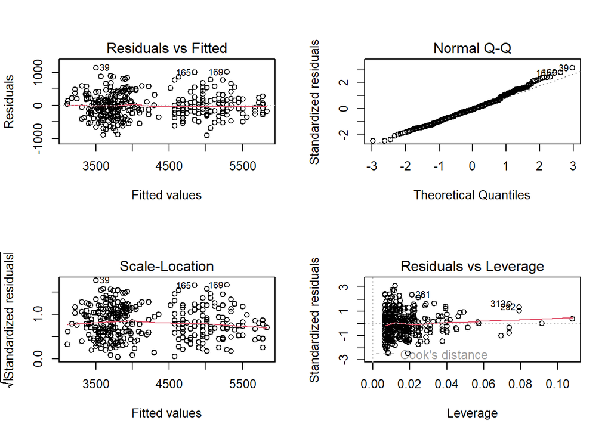

```r
# A 2 by 2 grid is set up to display four diagnostic plots on one page
par(mfrow = c(2,2))
# The four diagnostic plots are produced: residuals vs. fitted (1), normal Q-Q (2), scale-location (3), and residuals vs. leverage (4).
plot(lm_bodymass_flippers)
```

The four diagnostic plots above suggest that the assumptions needed to perform the linear regression analysis on this dataset have been met. The results of the linear regression model are shown and discussed below.

### Results and discussion

The results figure and supplementary below demonstrates the use of linear regression above:

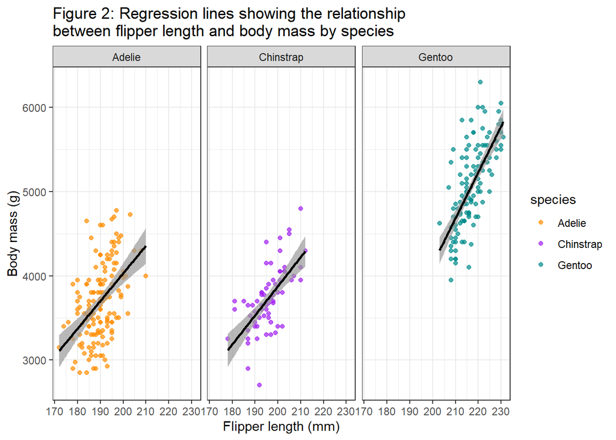

```r
# Plotting the results of the linear regression model by species

lm_results_figure <- ggplot(penguins_flippers_bodymass,
       aes(x = flipper_length_mm,
           y = body_mass_g,
           color = species)) + # Plots data, colourd by species for clarity
  geom_point(alpha = 0.7) +
  geom_smooth(method = "lm",
              se = TRUE,
              color = "black",
              alpha = 0.7) + # Fits a regression line and shows standard error
  facet_wrap(~species) + # For easy comparison of relationship by species
  labs(title = "Figure 2: Regression lines showing the relationship \nbetween flipper length and body mass by species",
       x = "Flipper length (mm)",
       y = "Body mass (g)") + # Axis labels for clarity
  theme_bw() + # For clarity, provides high contrast
  scale_colour_manual(values = species_colours) # Consistent colours across graphs

# Show the results figure
lm_results_figure
```

```r
# Supplementing the plot with a cleaner results table
results_table <- tidy(lm_bodymass_flippers)
# View the results table
results_table
```

```
## # A tibble: 6 × 5
##   term                               estimate std.error statistic  p.value
##   <chr>                                 <dbl>     <dbl>     <dbl>    <dbl>
## 1 (Intercept)                        -2536.      879.      -2.88  4.19e- 3
## 2 flipper_length_mm                     32.8       4.63     7.10  7.69e-12
## 3 speciesChinstrap                    -501.     1523.      -0.329 7.42e- 1
## 4 speciesGentoo                      -4251.     1427.      -2.98  3.11e- 3
## 5 flipper_length_mm:speciesChinstrap     1.74      7.86     0.222 8.25e- 1
## 6 flipper_length_mm:speciesGentoo       21.8       6.94     3.14  1.84e- 3
```

These results suggest that a longer flipper length is predictive of greater body mass across all three species. This is indicated by the adjusted R-squared, 0.7864 - 78.64% of variability in body mass is explained by flipper length and species. In addition, the F-statistic and its low P-value suggest that the model is significant in explaining this variation.

### Conclusions

This relationship has promising applications for studying these penguins. For example, where body mass cannot be measured, flipper length could be determined from images of penguins and then used to estimate body mass, in order to answer interesting questions like how the body mass of penguins is changing over time, such as in response to climate change. This could be useful to enable remote monitoring and increase the ease of gathering data without disrupting the penguins and avoiding any potential distress that could arise by handling them. (Maise et al. 2014)

However, this analysis has a number of limitations. Firstly, there is the potential for pseudo-replication because multiple measurements have been taken from the same individuals across years. Future analyses should control for this to prevent related data points being treated as independent, potentially skewing the data. A further limitation is that the model does not examine how this relationship differs among sexes, though sexual dimorphism has been observed in these penguins and previous work has looked into this. (Gorman et al. 2014)

Further work could expand on this analysis by investigating whether the relationship between flipper length and body mass differs among sexes, as well as whether other variables within the dataset, like culmen length and depth can be used to predict body mass. Further work could also investigate whether the length of flipper bones predict body mass in these species to study the evolution of the Adelie, Chinstrap, and Gentoo penguins and their flippers as has been done in other species using the humerus (for example: Ksepka, 2023).

In conclusion, we find that **flipper length is a strong predictor of body mass** across Adelie, Chinstrap, and Gentoo penguins, but that this relationship is stronger in Gentoo penguins. This has potential applications for penguin monitoring but also plenty of avenues for future research.

### References

- Campione and Evans, (2012), ‘A universal scaling relationship between body mass and proximal limb bone dimensions in quadrupedal terrestrial tetrapods’ *BMC Biol* **10**, 60, https://doi.org/10.1186/1741-7007-10-60
- Gorman et al. (2014), ‘Ecological Sexual Dimorphism and Environmental Variability within a Community of Antarctic Penguins (Genus *Pygoscelis*)’, PLoS One, https://doi.org/10.1371/journal.pone.0090081
- Jadwiszczak, (2001), ‘Body size of Eocene Antarctic penguins’, Polish Polar Research, 22, 2, 147-158.
- Jadwiszczak and Mors, (2011), ‘Aspects of diversity in early Antarctic penguins’, Acta Palaeontologica Polonica, 56(2), 269-277, http://dx.doi.org/10.4202/app.2009.1107
- Ksepka, (2023), ‘Largest-known fossil penguin provides insight into the early evolution of sphenisciform body size and flipper anatomy’, Journal of Paleontology, 97(2), pp. 434–453. doi:10.1017/jpa.2022.88.
- Meise et al. (2014), ‘Applicability of Single-Camera Photogrammetry to Determine Body Dimensions of Pinnipeds: Galapagos Sea Lions as an Example’,PLoS One, 2;9(7), https://doi.org/10.1371/journal.pone.0101197
- Whitlock & Schluter (2020), ‘The analysis of biological data’, Third Edition, Macmillan International Higher Education.

## Question 3: Open Science

### a) My GitHub

*GitHub link:* https://github.com/dinosaur84/ReproducibleScienceAndFigures/tree/main

### b) Share your repo with a partner, download, and try to run their data pipeline.

*Partner’s GitHub link:* https://github.com/Fungal03/Penguin_Project

### c) Reflect on your experience running their code. (300-500 words)

*What elements of your partner’s code helped you to understand and run their data pipeline?*

My partner’s code could be easily understood and run because it had a logical structure, and all necessary packages (and purposes) were indicated. This structure, based on the headings of a scientific paper, made it relatively easy to follow, while there were annotations to make the purpose of elements clear.

They provided clear graphs and tables that were easy to interpret, and this helped me to understand and run their data pipeline and their analysis. The repository was also well organised and provided all the elements necessary for their pipeline, including a cleaning.R script that detailed the data cleaning process in a manner that was easily reproducible and could be applied to use the dataset for different purposes.

*Did it run? Did you need to fix anything?*

The pipeline ran well - nothing needed to be fixed.

*What suggestions would you make for improving their code to make it more understandable or reproducible, and why?*

I have a number of suggestions to make their code more reproducible and understandable:

- They could have added a formatted title at the top of their .Rmd (but below the yaml) and included a note on the purpose of the script. This would make the script more understandable and reduce the risk of confusing the script with another should multiple be open simultaneously.
- They could have used a pipeline for the data cleaning process instead of a series of separate functions. This would help make the code more efficient and easier to understand by combining each of the functions used to clean the data.
- To improve the reproducibility of their code, my partner could have used renv to create a reproducible environment and enable the project library to be restored from a lock file. This is helpful for reproducibility because it goes beyond simply providing package names (though this is very helpful) but it goes further and records the exact versions of packages used and installs the versions used in the original analysis. Given that packages are frequently updated and sometimes updates may affect functionality, this is important because without using the same version of a package, our ability to replicate the analysis could be impaired.

*If you needed to alter your partner’s figure using their code, do you think that would be easy or difficult, and why?*

I think it would be easy because the code is laid out well. Separate lines are mostly used to denote new elements of the plots and annotations are provided, making each of the figures easy to edit. This could have been further facilitated by using a new line for new functions within the plot in each case.

### d) Reflect on your own code based on your experience with your partner’s code and their review of yours. (300-500 words)

#### What improvements did they suggest, and do you agree?

My partner suggested that I explain how the diagnostic plots in my analysis inform the suitability of the data for the linear model. They suggested I supplement my discussion by including this because of the potential for confusion should anyone attempt to replicate this analysis. To implement this suggestion, I would add a section to my discussion that describes the output of the four plots, how they inform the reader on whether assumptions of the analysis are met, and an evaluation of their output. I agree with their suggestion and think it would be helpful to increase understanding of the analysis.

They also suggested that I should annotate the function of all the packages the analysis loads in to increase clarity for the reader. I agree that this could make things easier, since currently only some of the packages are labelled (and none for question 1) and this would be important for greater consistency within the analysis.

#### What did you learn about writing code for other people?

This assignment demonstrated the practicalities of writing code not just for myself, but for other people to use and understand in practice. It encouraged me to stop and think about how to lay out and annotate my code in the best way possible, not just so others could run it but in case the methods I used were to be applied to analyse another dataset or different aspects of the same dataset.

I found this helpful in learning to practice reproducibility - what seems obvious may not be to others or even to myself in a couple of weeks. In addition, I was pleased to learn new ways to improve from my partner in the process and would put these improvements in place to increase the readability and reproducibility of my analysis.

### e) What are the main barriers for scientists to share their data and code, and what could be done to overcome them?

Open, reproducible, and transparent research (including through the sharing of data and code) remains rare in biology. (Gomes et al. 2022; Maitner et al. 2024) Though reproducibility and transparency are fundamental for science (Maitner et al. 2024), this is deeply worrying but also unsurprising, given the widespread perception that science faces a reproducibility crisis. (Baker, 2016) Overcoming the barriers that scientists face in sharing their data and code will therefore be a difficult process but a critical one to advance science for the benefit of society.

Gomes et al. (2022) propose 3 broad types of barriers that prevent scientists from sharing their data and code: knowledge barriers, reuse concerns, and disincentives.

Knowledge barriers include issues like not knowing how to share code/data, not knowing how to capture processes in a way that is reproducible, the logistical barrier large datasets present, but also insecurity about flaws or imperfections in code. A lack of knowledge on constructing reproducible code reduces incentives to re-use code, but this barrier can be overcome by sharing resources (with many resources made but remain neglected) to teach reproducible coding practices. Overcoming insecurity or fear associated with data/code sharing will be particularly difficult and will require individuals to shift their attitude towards the process of coding, but also attitude changes on the level of working groups and institutions.

Reuse concerns include issues like inappropriate use/misinterpretation of code, navigating sharing code/data where there are complex ownership and rights arrangements, worries over the long-term usability of data in its shared form, and the issue of sensitive content (given that some biological information can be harness for nefarious purposes, like bioterrorism). One way to overcome this is by publishing in repositories that allow the adjustment of permissions and access/reuse rights, including enabling the prevention of data use for commercial purposes.

Disincentives can also discourage scientists from sharing their code. For example, lack of time to complete the upfront steps needed to produce and share data/code for reproducible processes, perception that there is a lack of benefit, or worries that data will be scooped (analyses completed on shared data by another researcher, which the original researcher had planned themselves). A greater understanding of the incentives that sharing data/code openly provides will be necessary to overcome this barrier, such as greater citation rates (Maitner et al. 2024) or greater capacity for collaboration with colleagues. Incentives can also be provided, such as by rewarding individuals that share data within an institution and punishing those that keep it hidden.

Overall, to overcome each of these barriers, there will need to be a culture change in science, both from the top-down (from journals, funding agencies, and research institutions) but also from the bottom-up (individual researchers and labs) (Gomes et al. 2022). For example, by changing attitudes and by reducing the pressure to publish a huge number of papers in top academic journals in a short amount of time, in order to receive or maintain funding. Such an atmosphere led to the case of once-prolific spider ecologist, Johnathan Pruitt, whose allegedly fabricated data was able to go undetected. (Treleaven, 2024) In particular, this case shows the need for normalising the expectation of transparency from researchers.

Orchestrating this culture change will require considerable and widespread effort, both among current researchers and, crucially, by providing the next generation of scientists with an education that is based on practicing the principles of reproducibility and openness in all scientific work. This will be essential to overcome knowledge barriers and increase understanding of the incentives associated with sharing code, like higher citation rates. (Maitner et al. 2024)

In conclusion, while scientists face barriers in sharing their data and code (such as knowledge barriers, reuse concerns, and disincentives), overcoming these barriers is possible but such shifts must be implemented on a system-wide level to create a scientific culture of greater openness and reproducibility to facilitate continued expansion of knowledge, for the good of society at large.

*References*

- Gomes et al. (2022), ‘Why don’t we share data and code? Perceived barriers and benefits to public archiving practices’, Proceedings of the Royal Society B, Vol. 289, Issue 1987, https://doi.org/10.1098/rspb.2022.1113
- Maitner et al. (2024), ‘Code sharing increases citations, but remains uncommon’, Ecology and Evolution, https://doi.org/10.1002/ece3.70030
- Trisovic et al. (2022), ‘A large-scale study on research code quality and execution’, Scientific Data, 9:60, https://doi.org/10.1038/s41597-022-01143-6
- Baker (2016), ‘1,500 scientists lift the lid on reproducibility’, Nature, Vol. 533, 452-454, https://doi.org/10.1038/533452a
- Treleaven, (2024), ‘A Rock-star Researcher Spun a Web of Lies – and Nearly Got Away with It’, The Walrus, https://thewalrus.ca/a-rock-star-researcher-spun-a-web-of-lies-and-nearly-got-away-with-it/